# S2.2.1 Baseline Trait PSMU CFA using WLSMV

Kunru Song

2026-07-18 16:49:00 +08:00

This report compares a general one-factor model with a correlated Core–Peripheral two-factor model for the 18 baseline Trait PSMU items. Mplus 8.7 is the computation engine. R and `MplusAutomation` create the model inputs, run Mplus, parse and validate the outputs, save the canonical model-result RDA, and create the final Excel workbook and SVG figures.

The baseline CFA is a supplementary trait-level replication. Its result does not determine the EMA within-person measurement structure.

# 1 Load and validate the S2.1 entry data

```r
input_environment <- new.env(parent = emptyenv())
loaded_objects <- load(input_file, envir = input_environment)

if (!identical(loaded_objects, "dat_step2_measurement")) {
  stop(
    "S2.1 RDA must contain only dat_step2_measurement; found: ",
    paste(loaded_objects, collapse = ", ")
  )
}

dat_step2_measurement <- input_environment$dat_step2_measurement
expected_components <- c("baseline", "ema", "item_map", "audit")

if (!identical(names(dat_step2_measurement), expected_components)) {
  stop("Unexpected dat_step2_measurement component structure.")
}

baseline_items <- paste0("V_BSMAS_", 1:18)
expected_columns <- c("Name_ID", baseline_items)
dat_baseline_cfa <- dat_step2_measurement$baseline |>
  dplyr::select(dplyr::all_of(expected_columns)) |>
  as.data.frame()

stopifnot(
  identical(names(dat_baseline_cfa), expected_columns),
  nrow(dat_baseline_cfa) == 209L,
  dplyr::n_distinct(dat_baseline_cfa$Name_ID) == 209L,
  !anyNA(dat_baseline_cfa),
  all(vapply(dat_baseline_cfa[baseline_items], is.numeric, logical(1))),
  all(vapply(
    dat_baseline_cfa[baseline_items],
    function(x) all(x %in% 1:5),
    logical(1)
  ))
)

input_audit <- data.frame(
  input_file = "Res_2_Data_for_Analysis/dat_step2_measurement.rda",
  input_md5 = unname(tools::md5sum(input_file)),
  generating_script = dat_step2_measurement$audit$generated_by,
  participants = nrow(dat_baseline_cfa),
  items = length(baseline_items),
  missing_item_cells = sum(is.na(dat_baseline_cfa[baseline_items])),
  observed_minimum = min(as.matrix(dat_baseline_cfa[baseline_items])),
  observed_maximum = max(as.matrix(dat_baseline_cfa[baseline_items])),
  stringsAsFactors = FALSE
)

knitr::kable(input_audit)
```

| input_file | input_md5 | generating_script | participants | items | missing_item_cells | observed_minimum | observed_maximum |
| --- | --- | --- | --- | --- | --- | --- | --- |
| Res_2_Data_for_Analysis/dat_step2_measurement.rda | 96e2c717ca280b21f3eab023b06698a5 | Step_2_Measurement_Models/S2_1_Prepare.Rmd | 209 | 18 | 0 | 1 | 5 |

# 2 Mplus-safe variables and item mapping

Mplus receives short unique names (`bs1`–`bs18`). The mapping below is retained in the result RDA and every extracted table so no item identity is lost.

```r
mplus_item_names <- paste0("bs", 1:18)

variable_map <- data.frame(
  item_number = 1:18,
  project_variable = baseline_items,
  mplus_variable = toupper(mplus_item_names),
  theoretical_group = ifelse(1:18 <= 6L, "Peripheral", "Core"),
  stringsAsFactors = FALSE
)

mplus_data <- dat_baseline_cfa[baseline_items]
names(mplus_data) <- mplus_item_names
mplus_data <- as.data.frame(mplus_data)

stopifnot(
  identical(names(mplus_data), mplus_item_names),
  nrow(mplus_data) == 209L,
  !anyNA(mplus_data),
  length(unique(substr(names(mplus_data), 1L, 8L))) == 18L
)

knitr::kable(variable_map)
```

| item_number | project_variable | mplus_variable | theoretical_group |
| --- | --- | --- | --- |
| 1 | V_BSMAS_1 | BS1 | Peripheral |
| 2 | V_BSMAS_2 | BS2 | Peripheral |
| 3 | V_BSMAS_3 | BS3 | Peripheral |
| 4 | V_BSMAS_4 | BS4 | Peripheral |
| 5 | V_BSMAS_5 | BS5 | Peripheral |
| 6 | V_BSMAS_6 | BS6 | Peripheral |
| 7 | V_BSMAS_7 | BS7 | Core |
| 8 | V_BSMAS_8 | BS8 | Core |
| 9 | V_BSMAS_9 | BS9 | Core |
| 10 | V_BSMAS_10 | BS10 | Core |
| 11 | V_BSMAS_11 | BS11 | Core |
| 12 | V_BSMAS_12 | BS12 | Core |
| 13 | V_BSMAS_13 | BS13 | Core |
| 14 | V_BSMAS_14 | BS14 | Core |
| 15 | V_BSMAS_15 | BS15 | Core |
| 16 | V_BSMAS_16 | BS16 | Core |
| 17 | V_BSMAS_17 | BS17 | Core |
| 18 | V_BSMAS_18 | BS18 | Core |

# 3 Model specifications

Both models treat the 1–5 responses as ordered categorical and use Mplus WLSMV with the Delta parameterization. The first item of each factor is the marker indicator under the Mplus default identification rule. No item parcel, correlated residual, cross-loading, or post-hoc modification is added.

```r
model_specs <- list(
  B1_OneFactor = list(
    label = "B1 One-factor",
    stem = "s2_2_1_b1_one_factor",
    title = "S2.2.1 WLSMV B1 one-factor baseline Trait PSMU CFA;",
    model = "trait BY bs1-bs18;"
  ),
  B2_CorePeripheral = list(
    label = "B2 Core-Peripheral",
    stem = "s2_2_1_b2_core_peripheral",
    title = "S2.2.1 WLSMV B2 correlated Core-Peripheral baseline Trait PSMU CFA;",
    model = paste(
      "periph BY bs1-bs6;",
      "core BY bs7-bs18;",
      "periph WITH core;",
      sep = "\n"
    )
  )
)

model_plan <- dplyr::bind_rows(lapply(names(model_specs), function(model_id) {
  specification <- model_specs[[model_id]]
  data.frame(
    model_id = model_id,
    model_label = specification$label,
    estimator = "WLSMV",
    parameterization = "DELTA",
    indicator_treatment = "Ordered categorical (1-5)",
    categorical_items = 18L,
    factors = ifelse(model_id == "B1_OneFactor", 1L, 2L),
    mplus_input = paste0(specification$stem, ".inp"),
    stringsAsFactors = FALSE
  )
}))

knitr::kable(model_plan)
```

| model_id | model_label | estimator | parameterization | indicator_treatment | categorical_items | factors | mplus_input |
| --- | --- | --- | --- | --- | --- | --- | --- |
| B1_OneFactor | B1 One-factor | WLSMV | DELTA | Ordered categorical (1-5) | 18 | 1 | s2_2_1_b1_one_factor.inp |
| B2_CorePeripheral | B2 Core-Peripheral | WLSMV | DELTA | Ordered categorical (1-5) | 18 | 2 | s2_2_1_b2_core_peripheral.inp |

# 4 Generate and run the Mplus 8.7 models

The `.dat`, `.inp`, and `.out` files are regenerated by this Rmd.

```r
run_mplus_cfa <- function(model_id, specification) {
  model_stem <- specification$stem
  data_path <- file.path(mplus_directory, paste0(model_stem, ".dat"))
  input_path <- file.path(mplus_directory, paste0(model_stem, ".inp"))
  output_path <- file.path(mplus_directory, paste0(model_stem, ".out"))

  mplus_object <- MplusAutomation::mplusObject(
    TITLE = paste(
      "! Author: Kunru Song",
      specification$title,
      sep = "\n"
    ),
    VARIABLE = "CATEGORICAL = bs1-bs18;",
    ANALYSIS = paste(
      "ESTIMATOR = WLSMV;",
      "PARAMETERIZATION = DELTA;",
      sep = "\n"
    ),
    MODEL = specification$model,
    OUTPUT = paste(
      "SAMPSTAT;",
      "STANDARDIZED(STDYX);",
      "CINTERVAL;",
      "RESIDUAL;",
      "MODINDICES(10);",
      "TECH1;",
      "TECH4;",
      sep = "\n"
    ),
    usevariables = mplus_item_names,
    rdata = mplus_data,
    autov = FALSE,
    quiet = TRUE
  )

  modeler_result <- MplusAutomation::mplusModeler(
    object = mplus_object,
    dataout = data_path,
    modelout = input_path,
    run = 1L,
    check = FALSE,
    varwarnings = TRUE,
    Mplus_command = mplus_command,
    writeData = "always",
    hashfilename = FALSE,
    killOnFail = TRUE,
    quiet = TRUE
  )

  if (!file.exists(output_path)) {
    stop("Mplus did not create the expected output: ", output_path)
  }

  input_lines <- readLines(input_path, warn = FALSE)
  output_lines <- readLines(output_path, warn = FALSE)
  author_present <- any(trimws(input_lines) == "! Author: Kunru Song")
  normal_termination <- any(grepl(
    "THE MODEL ESTIMATION TERMINATED NORMALLY",
    output_lines,
    fixed = TRUE
  ))

  if (!author_present) stop("Missing required author text in: ", input_path)
  if (!normal_termination) stop("Mplus model did not terminate normally: ", output_path)

  parsed <- MplusAutomation::readModels(
    target = output_path,
    what = "all",
    quiet = TRUE
  )

  list(
    model_id = model_id,
    model_label = specification$label,
    model_syntax = specification$model,
    paths = list(data = data_path, input = input_path, output = output_path),
    author_present = author_present,
    normal_termination = normal_termination,
    parsed = parsed,
    modeler_result = modeler_result
  )
}

model_runs <- lapply(names(model_specs), function(model_id) {
  run_mplus_cfa(model_id, model_specs[[model_id]])
})
names(model_runs) <- names(model_specs)
```

# 5 Validate parsed Mplus output

Technical admissibility is evaluated separately from global model fit. Poor fit does not cause a technically valid model run to be discarded.

```r
flatten_messages <- function(x) {
  if (length(x) == 0L) return(NA_character_)
  values <- unlist(x, recursive = TRUE, use.names = FALSE)
  values <- trimws(as.character(values))
  values <- values[nzchar(values)]
  if (!length(values)) NA_character_ else paste(unique(values), collapse = " | ")
}

extract_loading_rows <- function(parsed) {
  standard <- parsed$parameters$stdyx.standardized
  standard[grepl("\\.BY$", standard$paramHeader), , drop = FALSE]
}

extract_factor_correlation_rows <- function(parsed) {
  standard <- parsed$parameters$stdyx.standardized
  standard[grepl("\\.WITH$", standard$paramHeader), , drop = FALSE]
}

technical_diagnostics <- dplyr::bind_rows(lapply(model_runs, function(run) {
  parsed <- run$parsed
  summary_row <- parsed$summaries[1, , drop = FALSE]
  loading_rows <- extract_loading_rows(parsed)
  factor_correlation_rows <- extract_factor_correlation_rows(parsed)
  r2_rows <- parsed$parameters$r2

  version_ok <- identical(as.character(summary_row$Mplus.version), "8.7")
  estimator_ok <- identical(as.character(summary_row$Estimator), "WLSMV")
  observations_ok <- identical(as.integer(summary_row$Observations), 209L)
  errors_n <- length(parsed$errors)
  warnings_n <- length(parsed$warnings)
  loadings_admissible <- all(is.finite(loading_rows$est)) &&
    all(abs(loading_rows$est) <= 1.001)
  residuals_admissible <- !is.null(r2_rows) &&
    all(is.finite(r2_rows$resid_var)) &&
    all(r2_rows$resid_var >= -0.001)
  correlations_admissible <- !nrow(factor_correlation_rows) ||
    all(abs(factor_correlation_rows$est) < 1)

  data.frame(
    model_id = run$model_id,
    model = run$model_label,
    mplus_version = as.character(summary_row$Mplus.version),
    estimator = as.character(summary_row$Estimator),
    observations = as.integer(summary_row$Observations),
    normal_termination = run$normal_termination,
    author_present = run$author_present,
    errors_n = errors_n,
    warnings_n = warnings_n,
    errors = flatten_messages(parsed$errors),
    warnings = flatten_messages(parsed$warnings),
    maximum_absolute_loading = max(abs(loading_rows$est)),
    minimum_residual_variance = min(r2_rows$resid_var),
    maximum_absolute_factor_correlation = if (nrow(factor_correlation_rows)) {
      max(abs(factor_correlation_rows$est))
    } else {
      NA_real_
    },
    version_ok = version_ok,
    estimator_ok = estimator_ok,
    observations_ok = observations_ok,
    loadings_admissible = loadings_admissible,
    residuals_admissible = residuals_admissible,
    correlations_admissible = correlations_admissible,
    technical_checks_passed = all(c(
      run$normal_termination,
      run$author_present,
      version_ok,
      estimator_ok,
      observations_ok,
      errors_n == 0L,
      loadings_admissible,
      residuals_admissible,
      correlations_admissible
    )),
    stringsAsFactors = FALSE
  )
}))

if (!all(technical_diagnostics$technical_checks_passed)) {
  stop(
    "At least one Mplus CFA failed technical validation: ",
    paste(
      technical_diagnostics$model[!technical_diagnostics$technical_checks_passed],
      collapse = ", "
    )
  )
}

knitr::kable(technical_diagnostics, digits = 3)
```

| model_id | model | mplus_version | estimator | observations | normal_termination | author_present | errors_n | warnings_n | errors | warnings | maximum_absolute_loading | minimum_residual_variance | maximum_absolute_factor_correlation | version_ok | estimator_ok | observations_ok | loadings_admissible | residuals_admissible | correlations_admissible | technical_checks_passed |
| --- | --- | --- | --- | --- | --- | --- | --- | --- | --- | --- | --- | --- | --- | --- | --- | --- | --- | --- | --- | --- |
| B1_OneFactor | B1 One-factor | 8.7 | WLSMV | 209 | TRUE | TRUE | 0 | 0 | NA | NA | 0.908 | 0.175 | NA | TRUE | TRUE | TRUE | TRUE | TRUE | TRUE | TRUE |
| B2_CorePeripheral | B2 Core-Peripheral | 8.7 | WLSMV | 209 | TRUE | TRUE | 0 | 0 | NA | NA | 0.915 | 0.163 | 0.802 | TRUE | TRUE | TRUE | TRUE | TRUE | TRUE | TRUE |

# 6 Extract fit and parameter results

```r
extract_fit <- function(run) {
  summary_row <- run$parsed$summaries[1, , drop = FALSE]
  data.frame(
    model_id = run$model_id,
    model = run$model_label,
    mplus_version = as.character(summary_row$Mplus.version),
    estimator = as.character(summary_row$Estimator),
    parameterization = "DELTA",
    n = as.integer(summary_row$Observations),
    free_parameters = as.integer(summary_row$Parameters),
    chi_square = as.numeric(summary_row$ChiSqM_Value),
    df = as.integer(summary_row$ChiSqM_DF),
    p_value = as.numeric(summary_row$ChiSqM_PValue),
    cfi = as.numeric(summary_row$CFI),
    tli = as.numeric(summary_row$TLI),
    rmsea = as.numeric(summary_row$RMSEA_Estimate),
    rmsea_90ci_lower = as.numeric(summary_row$RMSEA_90CI_LB),
    rmsea_90ci_upper = as.numeric(summary_row$RMSEA_90CI_UB),
    rmsea_p_close = as.numeric(summary_row$RMSEA_pLT05),
    srmr = as.numeric(summary_row$SRMR),
    stringsAsFactors = FALSE
  )
}

model_fit <- dplyr::bind_rows(lapply(model_runs, extract_fit)) |>
  dplyr::mutate(
    delta_cfi_vs_b1 = c(NA_real_, cfi[2] - cfi[1]),
    delta_tli_vs_b1 = c(NA_real_, tli[2] - tli[1]),
    delta_rmsea_vs_b1 = c(NA_real_, rmsea[2] - rmsea[1]),
    delta_srmr_vs_b1 = c(NA_real_, srmr[2] - srmr[1])
  )

extract_loadings <- function(run) {
  parsed <- run$parsed
  standard <- extract_loading_rows(parsed)
  standard_ci <- parsed$parameters$ci.stdyx.standardized
  standard_ci <- standard_ci[
    grepl("\\.BY$", standard_ci$paramHeader),
    c("paramHeader", "param", "low2.5", "up2.5"),
    drop = FALSE
  ]
  unstandard <- parsed$parameters$unstandardized
  unstandard <- unstandard[
    grepl("\\.BY$", unstandard$paramHeader),
    c("paramHeader", "param", "est", "se"),
    drop = FALSE
  ]
  names(unstandard)[3:4] <- c("unstandardized_loading", "unstandardized_se")
  r2 <- parsed$parameters$r2[, c("param", "est", "resid_var"), drop = FALSE]
  names(r2)[2] <- "r_squared"

  result <- standard |>
    dplyr::select(
      paramHeader,
      param,
      standardized_loading = est,
      standardized_se = se,
      standardized_z = est_se,
      standardized_p = pval
    ) |>
    dplyr::left_join(standard_ci, by = c("paramHeader", "param")) |>
    dplyr::left_join(unstandard, by = c("paramHeader", "param")) |>
    dplyr::left_join(r2, by = "param") |>
    dplyr::left_join(variable_map, by = c("param" = "mplus_variable")) |>
    dplyr::mutate(
      model_id = run$model_id,
      model = run$model_label,
      factor = sub("\\.BY$", "", paramHeader),
      standardized_ci_lower = low2.5,
      standardized_ci_upper = up2.5
    ) |>
    dplyr::select(
      model_id,
      model,
      factor,
      item_number,
      project_variable,
      theoretical_group,
      unstandardized_loading,
      unstandardized_se,
      standardized_loading,
      standardized_se,
      standardized_z,
      standardized_p,
      standardized_ci_lower,
      standardized_ci_upper,
      r_squared,
      residual_variance = resid_var
    ) |>
    dplyr::arrange(item_number)

  result
}

loadings <- dplyr::bind_rows(lapply(model_runs, extract_loadings))

extract_factor_correlation <- function(run) {
  standard <- extract_factor_correlation_rows(run$parsed)
  if (!nrow(standard)) return(NULL)

  standard_ci <- run$parsed$parameters$ci.stdyx.standardized
  standard_ci <- standard_ci[
    grepl("\\.WITH$", standard_ci$paramHeader),
    c("paramHeader", "param", "low2.5", "up2.5"),
    drop = FALSE
  ]

  standard |>
    dplyr::select(
      paramHeader,
      param,
      correlation = est,
      se,
      z = est_se,
      p_value = pval
    ) |>
    dplyr::left_join(standard_ci, by = c("paramHeader", "param")) |>
    dplyr::transmute(
      model_id = run$model_id,
      model = run$model_label,
      factor_1 = sub("\\.WITH$", "", paramHeader),
      factor_2 = param,
      correlation = correlation,
      se = se,
      z = z,
      p_value = p_value,
      ci_lower = low2.5,
      ci_upper = up2.5
    )
}

factor_correlations <- dplyr::bind_rows(lapply(model_runs, extract_factor_correlation))

loading_summary <- loadings |>
  dplyr::group_by(model_id, model, factor) |>
  dplyr::summarise(
    items = dplyr::n(),
    minimum_standardized_loading = min(standardized_loading),
    mean_standardized_loading = mean(standardized_loading),
    maximum_standardized_loading = max(standardized_loading),
    minimum_r_squared = min(r_squared),
    maximum_r_squared = max(r_squared),
    .groups = "drop"
  )

knitr::kable(model_fit, digits = 3)
```

| model_id | model | mplus_version | estimator | parameterization | n | free_parameters | chi_square | df | p_value | cfi | tli | rmsea | rmsea_90ci_lower | rmsea_90ci_upper | rmsea_p_close | srmr | delta_cfi_vs_b1 | delta_tli_vs_b1 | delta_rmsea_vs_b1 | delta_srmr_vs_b1 |
| --- | --- | --- | --- | --- | --- | --- | --- | --- | --- | --- | --- | --- | --- | --- | --- | --- | --- | --- | --- | --- |
| B1_OneFactor | B1 One-factor | 8.7 | WLSMV | DELTA | 209 | 90 | 1269.320 | 135 | 0 | 0.866 | 0.848 | 0.201 | 0.191 | 0.211 | 0 | 0.098 | NA | NA | NA | NA |
| B2_CorePeripheral | B2 Core-Peripheral | 8.7 | WLSMV | DELTA | 209 | 91 | 1062.611 | 134 | 0 | 0.891 | 0.875 | 0.182 | 0.172 | 0.192 | 0 | 0.091 | 0.025 | 0.027 | -0.019 | -0.007 |

```r
knitr::kable(loading_summary, digits = 3)
```

| model_id | model | factor | items | minimum_standardized_loading | mean_standardized_loading | maximum_standardized_loading | minimum_r_squared | maximum_r_squared |
| --- | --- | --- | --- | --- | --- | --- | --- | --- |
| B1_OneFactor | B1 One-factor | TRAIT | 18 | 0.527 | 0.770 | 0.908 | 0.278 | 0.825 |
| B2_CorePeripheral | B2 Core-Peripheral | CORE | 12 | 0.740 | 0.821 | 0.915 | 0.548 | 0.837 |
| B2_CorePeripheral | B2 Core-Peripheral | PERIPH | 6 | 0.589 | 0.763 | 0.865 | 0.347 | 0.748 |

```r
knitr::kable(factor_correlations, digits = 3)
```

| model_id | model | factor_1 | factor_2 | correlation | se | z | p_value | ci_lower | ci_upper |
| --- | --- | --- | --- | --- | --- | --- | --- | --- | --- |
| B2_CorePeripheral | B2 Core-Peripheral | PERIPH | CORE | 0.802 | 0.021 | 38.876 | 0 | 0.762 | 0.843 |

# 7 Save the canonical parsed model-result RDA

```r
project_root_normalized <- normalizePath(project_root, winslash = "/", mustWork = TRUE)

make_relative_path <- function(path) {
  normalized <- normalizePath(path, winslash = "/", mustWork = TRUE)
  root_prefix <- paste0(project_root_normalized, "/")
  if (startsWith(normalized, root_prefix)) {
    substring(normalized, nchar(root_prefix) + 1L)
  } else {
    normalized
  }
}

mplus_file_manifest <- dplyr::bind_rows(lapply(model_runs, function(run) {
  data.frame(
    model_id = run$model_id,
    model = run$model_label,
    file_type = c("data", "input", "output"),
    relative_path = vapply(run$paths, make_relative_path, character(1)),
    md5 = unname(tools::md5sum(unlist(run$paths))),
    stringsAsFactors = FALSE
  )
}))

fit_s2_2_1_baseline_cfa_wlsmv <- list(
  metadata = list(
    generated_by = "Step_2_Measurement_Models/S2_2_1_BaselineCFA_PSMU18items_WLSMV.Rmd",
    input_file = "Res_2_Data_for_Analysis/dat_step2_measurement.rda",
    input_md5 = unname(tools::md5sum(input_file)),
    mplus_executable = normalizePath(mplus_command, winslash = "/", mustWork = TRUE),
    mplus_version = unique(technical_diagnostics$mplus_version),
    mplusautomation_version = as.character(utils::packageVersion("MplusAutomation")),
    estimator = "WLSMV",
    parameterization = "DELTA"
  ),
  variable_map = variable_map,
  model_plan = model_plan,
  model_fit = model_fit,
  loadings = loadings,
  loading_summary = loading_summary,
  factor_correlations = factor_correlations,
  diagnostics = technical_diagnostics,
  mplus_files = mplus_file_manifest,
  parsed_models = lapply(model_runs, function(run) run$parsed)
)

save(fit_s2_2_1_baseline_cfa_wlsmv, file = model_result_file, compress = "xz", version = 3)

verification_environment <- new.env(parent = emptyenv())
verified_objects <- load(model_result_file, envir = verification_environment)
stopifnot(
  identical(verified_objects, "fit_s2_2_1_baseline_cfa_wlsmv"),
  identical(
    verification_environment$fit_s2_2_1_baseline_cfa_wlsmv$metadata$generated_by,
    "Step_2_Measurement_Models/S2_2_1_BaselineCFA_PSMU18items_WLSMV.Rmd"
  ),
  all(verification_environment$fit_s2_2_1_baseline_cfa_wlsmv$diagnostics$technical_checks_passed)
)
```

# 8 Export the final result workbook in R

```r
round_numeric_columns <- function(data, digits = 4L) {
  data |>
    dplyr::mutate(dplyr::across(where(is.numeric), ~ round(.x, digits))) |>
    dplyr::mutate(dplyr::across(where(is.factor), as.character))
}

workbook_sheets <- list(
  Model_Fit = round_numeric_columns(model_fit),
  Loadings = round_numeric_columns(loadings),
  Factor_Correlation = round_numeric_columns(factor_correlations),
  Diagnostics = round_numeric_columns(technical_diagnostics)
)

bruceR::export(
  workbook_sheets,
  file = table_file,
  overwrite = TRUE,
  verbose = FALSE
)

# Apply a reproducible scientific-results format in R after the required
# bruceR export. This preserves typed numeric cells while improving reviewability.
workbook <- openxlsx::loadWorkbook(table_file)
header_style <- openxlsx::createStyle(
  fontName = "Arial",
  fontSize = 10,
  fontColour = "#FFFFFF",
  fgFill = "#1F4E78",
  textDecoration = "bold",
  halign = "center",
  valign = "center",
  wrapText = TRUE,
  border = "bottom",
  borderColour = "#163A5C"
)
decimal_style <- openxlsx::createStyle(numFmt = "0.000")
integer_style <- openxlsx::createStyle(numFmt = "#,##0")

integer_column_names <- c(
  "n",
  "df",
  "free_parameters",
  "item_number",
  "errors_n",
  "warnings_n",
  "observations"
)

for (sheet_name in names(workbook_sheets)) {
  sheet_data <- workbook_sheets[[sheet_name]]
  n_rows <- nrow(sheet_data)
  n_columns <- ncol(sheet_data)

  openxlsx::addStyle(
    workbook,
    sheet = sheet_name,
    style = header_style,
    rows = 1,
    cols = seq_len(n_columns),
    gridExpand = TRUE,
    stack = TRUE
  )
  openxlsx::setRowHeights(workbook, sheet_name, rows = 1, heights = 30)
  openxlsx::freezePane(workbook, sheet_name, firstRow = TRUE)
  openxlsx::addFilter(workbook, sheet_name, rows = 1, cols = seq_len(n_columns))
  openxlsx::showGridLines(workbook, sheet_name, showGridLines = FALSE)

  column_widths <- vapply(seq_len(n_columns), function(column_index) {
    values <- c(names(sheet_data)[column_index], as.character(sheet_data[[column_index]]))
    values[is.na(values)] <- ""
    min(38, max(10, max(nchar(values), na.rm = TRUE) + 2))
  }, numeric(1))
  openxlsx::setColWidths(
    workbook,
    sheet = sheet_name,
    cols = seq_len(n_columns),
    widths = column_widths
  )

  if (n_rows > 0L) {
    numeric_columns <- which(vapply(sheet_data, is.numeric, logical(1)))
    integer_columns <- which(names(sheet_data) %in% integer_column_names)
    decimal_columns <- setdiff(numeric_columns, integer_columns)

    if (length(integer_columns)) {
      openxlsx::addStyle(
        workbook,
        sheet = sheet_name,
        style = integer_style,
        rows = 2:(n_rows + 1L),
        cols = integer_columns,
        gridExpand = TRUE,
        stack = TRUE
      )
    }
    if (length(decimal_columns)) {
      openxlsx::addStyle(
        workbook,
        sheet = sheet_name,
        style = decimal_style,
        rows = 2:(n_rows + 1L),
        cols = decimal_columns,
        gridExpand = TRUE,
        stack = TRUE
      )
    }
  }
}

openxlsx::saveWorkbook(workbook, table_file, overwrite = TRUE)

# openxlsx can retain orphan drawing relationships introduced by the original
# bruceR workbook even though no drawing parts are present. Excel tolerates
# them, but stricter OOXML readers do not. Remove only those two orphan
# relationship types, leaving worksheet data, styles, and printer settings
# unchanged.
repair_orphan_drawing_relationships <- function(xlsx_file) {
  repair_dir <- tempfile("s2_2_1_xlsx_repair_")
  dir.create(repair_dir)
  on.exit(unlink(repair_dir, recursive = TRUE, force = TRUE), add = TRUE)

  utils::unzip(xlsx_file, exdir = repair_dir)
  relationship_files <- list.files(
    file.path(repair_dir, "xl", "worksheets", "_rels"),
    pattern = "\\.rels$",
    full.names = TRUE
  )
  stopifnot(length(relationship_files) > 0L)

  orphan_pattern <- paste0(
    '<Relationship[^>]+Type="http://schemas\\.openxmlformats\\.org/',
    'officeDocument/2006/relationships/(drawing|vmlDrawing)"[^>]*/>'
  )
  removed_relationships <- 0L

  for (relationship_file in relationship_files) {
    xml_text <- paste(readLines(relationship_file, warn = FALSE), collapse = "\n")
    matches <- gregexpr(orphan_pattern, xml_text, perl = TRUE)[[1L]]
    removed_relationships <- removed_relationships +
      if (identical(matches, -1L)) 0L else length(matches)
    repaired_text <- gsub(orphan_pattern, "", xml_text, perl = TRUE)
    writeLines(repaired_text, relationship_file, useBytes = TRUE)
  }

  stopifnot(removed_relationships > 0L)
  repaired_file <- tempfile(fileext = ".xlsx")
  archive_members <- list.files(
    repair_dir,
    recursive = TRUE,
    all.files = TRUE,
    no.. = TRUE
  )
  zip::zipr(
    zipfile = repaired_file,
    files = archive_members,
    root = repair_dir,
    include_directories = FALSE,
    mode = "mirror"
  )
  stopifnot(file.exists(repaired_file), file.info(repaired_file)$size > 0)
  stopifnot(file.copy(repaired_file, xlsx_file, overwrite = TRUE))

  invisible(removed_relationships)
}

orphan_relationships_removed <- repair_orphan_drawing_relationships(table_file)

stopifnot(
  file.exists(table_file),
  identical(
    openxlsx::getSheetNames(table_file),
    names(workbook_sheets)
  )
)
```

# 9 Visualize model fit and standardized loadings in R

Reference lines indicate conventional fit guidelines; model selection also requires substantive and diagnostic assessment.

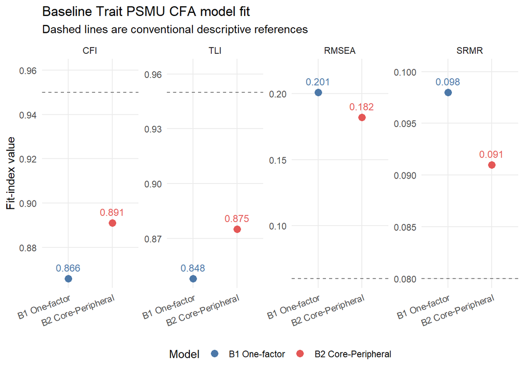

```r
fit_plot_data <- model_fit |>
  dplyr::select(model, cfi, tli, rmsea, srmr) |>
  tidyr::pivot_longer(
    cols = c(cfi, tli, rmsea, srmr),
    names_to = "fit_index",
    values_to = "value"
  ) |>
  dplyr::mutate(
    fit_index = factor(
      fit_index,
      levels = c("cfi", "tli", "rmsea", "srmr"),
      labels = c("CFI", "TLI", "RMSEA", "SRMR")
    ),
    model = factor(
      model,
      levels = c("B1 One-factor", "B2 Core-Peripheral")
    )
  )

fit_references <- data.frame(
  fit_index = factor(
    c("CFI", "TLI", "RMSEA", "SRMR"),
    levels = c("CFI", "TLI", "RMSEA", "SRMR")
  ),
  reference = c(.95, .95, .06, .08)
)

fit_figure <- ggplot2::ggplot(
  fit_plot_data,
  ggplot2::aes(x = model, y = value, color = model)
) +
  ggplot2::geom_hline(
    data = fit_references,
    ggplot2::aes(yintercept = reference),
    inherit.aes = FALSE,
    linetype = "dashed",
    color = "grey45",
    linewidth = .5
  ) +
  ggplot2::geom_point(size = 3) +
  ggplot2::geom_text(
    ggplot2::aes(label = sprintf("%.3f", value)),
    vjust = -1,
    show.legend = FALSE,
    size = 3.3
  ) +
  ggplot2::facet_wrap(~ fit_index, scales = "free_y", nrow = 1) +
  ggplot2::scale_y_continuous(expand = ggplot2::expansion(mult = c(.05, .18))) +
  ggplot2::scale_color_manual(values = c("#4C78A8", "#E45756")) +
  ggplot2::labs(
    title = "Baseline Trait PSMU CFA model fit",
    subtitle = "Dashed lines are conventional descriptive references",
    x = NULL,
    y = "Fit-index value",
    color = "Model"
  ) +
  ggplot2::theme_minimal(base_size = 11) +
  ggplot2::theme(
    axis.text.x = ggplot2::element_text(angle = 20, hjust = 1),
    legend.position = "bottom",
    panel.grid.minor = ggplot2::element_blank()
  )

ggplot2::ggsave(
  filename = fit_figure_file,
  plot = fit_figure,
  device = "svg",
  width = 10,
  height = 4.8,
  units = "in",
  bg = "white"
)

fit_figure
```

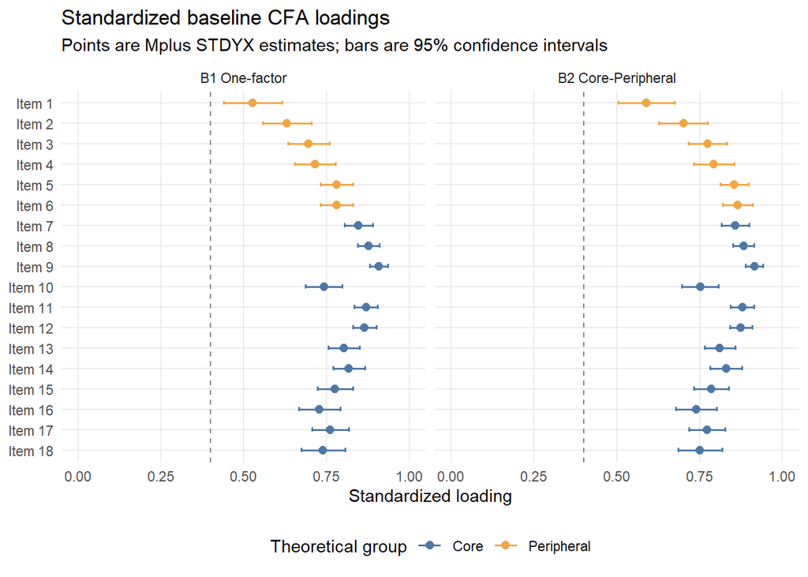

```r
loading_plot_data <- loadings |>
  dplyr::mutate(
    item_label = factor(
      paste0("Item ", item_number),
      levels = rev(paste0("Item ", 1:18))
    ),
    model = factor(
      model,
      levels = c("B1 One-factor", "B2 Core-Peripheral")
    )
  )

loading_figure <- ggplot2::ggplot(
  loading_plot_data,
  ggplot2::aes(
    x = standardized_loading,
    y = item_label,
    color = theoretical_group
  )
) +
  ggplot2::geom_vline(
    xintercept = .40,
    linetype = "dashed",
    color = "grey50",
    linewidth = .5
  ) +
  ggplot2::geom_errorbar(
    ggplot2::aes(
      xmin = standardized_ci_lower,
      xmax = standardized_ci_upper
    ),
    orientation = "y",
    width = .20,
    linewidth = .55
  ) +
  ggplot2::geom_point(size = 2.2) +
  ggplot2::facet_wrap(~ model, nrow = 1) +
  ggplot2::scale_color_manual(
    values = c("Peripheral" = "#F2A541", "Core" = "#4C78A8")
  ) +
  ggplot2::coord_cartesian(xlim = c(0, 1)) +
  ggplot2::labs(
    title = "Standardized baseline CFA loadings",
    subtitle = "Points are Mplus STDYX estimates; bars are 95% confidence intervals",
    x = "Standardized loading",
    y = NULL,
    color = "Theoretical group"
  ) +
  ggplot2::theme_minimal(base_size = 11) +
  ggplot2::theme(
    legend.position = "bottom",
    panel.grid.minor = ggplot2::element_blank()
  )

ggplot2::ggsave(
  filename = loading_figure_file,
  plot = loading_figure,
  device = "svg",
  width = 10,
  height = 8.5,
  units = "in",
  bg = "white"
)

loading_figure
```

# 10 Interpretation

Both models were estimated by Mplus 8.7 with WLSMV and passed the prespecified technical checks. The one-factor model had CFI = 0.866, TLI = 0.848, RMSEA = 0.201, and SRMR = 0.098. The correlated Core–Peripheral model had CFI = 0.891, TLI = 0.875, RMSEA = 0.182, and SRMR = 0.091. Its standardized Core–Peripheral correlation was 0.802 (95% CI [0.762, 0.843]).

The two-factor model improves all four reported fit indices relative to the one-factor model, but its absolute fit remains poor by conventional descriptive guides. The better relative fit does not establish that the two-factor model fits adequately. This supplementary baseline analysis does not determine the EMA measurement structure. No post-hoc residual correlation or cross-loading was added after observing the fit.